# [CptS 215 Data Analytics Systems and Algorithms](https://piazza.com/wsu/fall2017/cpts215/home)

[Washington State University](https://wsu.edu)

[Gina Sprint](http://eecs.wsu.edu/~gsprint/)

## MA5 Tree Practice (50 pts)

Due:

### Learner Objectives

At the conclusion of this micro assignment, participants should be able to:

- Implement/analyze trees
  - Binary trees
  - Binary search trees
  - AVL trees

### Prerequisites

Before starting this micro assignment, participants should be able to:

- Write object oriented Python code
- Write Markdown and code cells in Jupyter Notebook
- Perform algorithm analysis

### Acknowledgments

Content used in this assignment is based upon information in the following sources:

- [Data Structures: Abstraction and Design Using Java](http://www.wiley.com/WileyCDA/WileyTitle/productCd-EHEP001607.html) by Koffman and Wolfgang

## Overview and Requirements

For this micro assignment, you are going to download this Jupyter Notebook and answer the following questions. Your answer for a problem should be in a cell *immediately* after the problem cell. *Do not modify the problem cell.*

We are going to solve several problems related to trees and their efficiency. This micro assignment includes conceptional questions and programming.

### Conceptual Questions

Solve the following problems and *justify* your answers:

1. For the following binary tree:

[figure not shown]

   1. (2 pts) Is the tree full?
   2. (2 pts) Is the tree complete?
   3. (2 pts) What is the tree's height?
   4. List the nodes in the tree in the order they would be visited during a:
      1. (4 pts) Pre-order traversal
      2. (4 pts) Level-order traversal
      3. (4 pts) Post-order traversal
      4. (4 pts) In-order traversal
2. (2 pts) What is the time complexity to search a full BST?
3. The following questions refer to the same BST. The operations are cumulative:
   1. (2 pts) Show the BST that would result from inserting the items 35, 20, 30, 50, 45, 60, 18, 25 in this sequence.
   2. (2 pts) Show the BST that would result after removing item 35 (promote in order successor).
   3. (2 pts) Show the BST that would result after removing item 18 (promote in order successor).
   4. (2 pts) How would the trees in the previous problems look differently if we promote in order predecessors instead of successors?
4. (2 pts) Given the following tree, perform the appropriate rotations to bring it back into balance:

[figure not shown]

   (image from http://interactivepython.org/runestone/static/pythonds/_images/rotexer1.png)

### Implementation Question

Write a program that implements and tests an AVL tree `remove(item)` method. This method accepts an item to remove. If the item is in the tree, the method removes the item, re-balances the tree, and returns `True`. If the item is not in the tree, `False` is returned.

### Conceptual questions:

1. It is not a full tree, because the bottom level is not full. It is a complete binary tree, because every level except for the bottoms is full. The hieght is 4, as we count levels. Pre order: *, A, 1, X, Y, 2, B, 3, 4 In order: X, 1, Y, A, 2, *, 3, B, 4 Post order: X, Y, 1, 2, A, 3, 4, B, * Leveled order: *, A, B, 1, 2, 3, 4, X, Y
2. It is O(N) because it has to traverse whole tree to find target in worst case. But on average it is O(log N).
3. A.

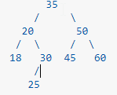

   B.

[figure not shown]

   C.

[figure not shown]

   D.

[figure not shown]

   4.

### Implementation Question:

```python
#!/usr/bin/python3
class BSTNode:
    '''
    Class that represends node in Binary Search Tree or AVL tree.
    '''
    def __init__(self, key, val, left=None, right=None, parent=None):
        '''

        '''
        self.key = key
        self.value = val
        self.left_child = left
        self.right_child = right
        self.parent = parent
        self.balance_factor = 0
        self.height = 1

    def __iter__(self):
        '''
        Yield freezes the state of the function so that the next time the function
        is called it continues executing from the exact point it left off earlier.
        '''
        if self:
            if self.has_left_child():
                 for elem in self.left_child:
                    yield elem
            yield self.key
            if self.has_right_child():
                 for elem in self.right_child:
                    yield elem

    def has_left_child(self):
        '''

        '''
        return self.left_child

    def has_right_child(self):
        '''

        '''
        return self.right_child

    def is_left_child(self):
        '''

        '''
        return self.parent and self.parent.left_child == self

    def is_right_child(self):
        '''

        '''
        return self.parent and self.parent.right_child == self

    def is_root(self):
        '''

        '''
        return not self.parent

    def is_leaf(self):
        '''

        '''
        return not (self.right_child or self.left_child)

    def has_any_children(self):
        '''

        '''
        return self.right_child or self.left_child

    def has_both_children(self):
        '''

        '''
        return self.right_child and self.left_child

    def replace_node_data(self, key, value, lc, rc):
        '''
        Overwrite this node's information with new information in the parameters
        '''
        self.key = key
        self.value = value
        self.left_child = lc
        self.right_child = rc
        if self.has_left_child():
            self.left_child.parent = self
        if self.has_right_child():
            self.right_child.parent = self

    def splice_out(self):
        '''
        Go directly to the node we want to splice out and makes the right changes.
        Handles case 1 and 2 of delete()
        No need to search for node to delete (unlike delete())
        '''
        if self.is_leaf(): # delete() case 1 (no children)
            if self.is_left_child():
                self.parent.left_child = None
            else:
                self.parent.right_child = None
        elif self.has_any_children(): # delete case 2 (exactly one child)
            if self.has_left_child():
                if self.is_left_child():
                    self.parent.left_child = self.left_child
                else:
                    self.parent.right_child = self.left_child
                self.left_child.parent = self.parent
            else:
                if self.is_left_child():
                    self.parent.left_child = self.right_child
                else:
                    self.parent.right_child = self.right_child
                self.right_child.parent = self.parent

    def find_successor(self):
        '''
        3 cases when looking for the successor:

        1. If the node has a right child, then the successor is the smallest key in the right subtree.
        2. If the node has no right child and is the left child of its parent, then the parent is the successor.
        3. If the node is the right child of its parent, and itself has no right child,
        then the successor to this node is the successor of its parent, excluding this node.
        '''
        succ = None
        if self.has_right_child():
            succ = self.right_child.find_min()
        else:
            if self.parent:
                if self.is_left_child():
                    succ = self.parent
                else:
                    self.parent.right_child = None
                    succ = self.parent.find_successor()
                    self.parent.right_child = self
        return succ

    def find_min(self):
        '''
        Find the minimum key in a subtree.
        Left-most child in the subtree.
        '''
        current = self
        while current.has_left_child():
            current = current.left_child
        return current

class BinarySearchTree:
    '''
    BinarySearchTree class.
    '''
    def __init__(self):
        '''

        '''
        self.root = None
        self.size = 0

    def length(self):
        '''

        '''
        return self.size

    def __len__(self):
        '''
        Return the number of key-value pairs stored in the map.
        '''
        return self.size

    def __iter__(self):
        '''

        '''
        return self.root.__iter__()

    def __setitem__(self, k, v):
        '''

        '''
        self.put(k,v)

    def __getitem__(self, key):
        '''

        '''
        return self.get(key)

    def __delitem__(self,key):
        '''
        Delete the key-value pair from the map using a statement of the form del map[key].
        '''
        self.delete(key)

    def __contains__(self, key):
        '''
        Return True for a statement of the form key in map, if the given key is in the map.
        '''
        if self._get(key, self.root):
            return True
        else:
            return False

    def put(self, key, val):
        '''
        Add a new key-value pair to the map.
        If the key is already in the map then replace the old value with the new value.

        If there is not a root then put will create a new TreeNode and install it as the root of the tree.
        If a root node is already in place then put calls the private, recursive, helper function _put to search the tree
        '''
        if self.root:
            self._put(key, val, self.root)
        else:
            self.root = BSTNode(key, val)
        self.size = self.size + 1
```

```python
    def _put(self, key, val, current_node):
        '''
        Starting at the root of the tree, search the binary tree comparing the new key
        to the key in the current node. If the new key is less than the current node,
        search the left subtree. If the new key is greater than the current node,
        search the right subtree.

        When there is no left (or right) child to search, we have found the position
        in the tree where the new node should be installed.

        To add a node to the tree, create a new TreeNode object and insert the object
        at the point discovered in the previous step.
        '''
        if key == current_node.key: # handle duplicates by updating value
            current_node.value = val
        elif key < current_node.key:
            if current_node.has_left_child():
                self._put(key, val, current_node.left_child)
            else:
                current_node.left_child = BSTNode(key, val, parent=current_node)
        else:
            if current_node.has_right_child():
                self._put(key, val, current_node.right_child)
            else:
                current_node.right_child = BSTNode(key, val, parent=current_node)

    def get(self, key):
        '''
        Given a key, return the value stored in the map or None otherwise.
        '''
        if self.root:
            res = self._get(key, self.root)
            if res:
                   return res.value
            else:
                   return None
        else:
            return None

    def _get(self, key, current_node):
        '''
        searches the tree recursively until it gets to a non-matching leaf node or finds a matching key.
        When a matching key is found, the value stored in the payload of the node is returned.
        '''
        if not current_node:
            return None
        elif current_node.key == key:
            return current_node
        elif key < current_node.key:
            return self._get(key, current_node.left_child)
        else:
            return self._get(key, current_node.right_child)

    def delete(self, key):
        '''
        Find the node to delete by searching the tree using the
        _get method to find the TreeNode that needs to be removed.

        If the tree only has a single node, that means we are removing the root of the tree,
        but we still must check to make sure the key of the root matches the key that is to be deleted.

        '''
        if self.size > 1:
            node_to_remove = self._get(key, self.root)
            if node_to_remove:
                self.remove(node_to_remove)
                self.size = self.size-1
            else:
                raise KeyError('Error, key not in tree')
        elif self.size == 1 and self.root.key == key:
            self.root = None
            self.size = self.size - 1
        else:
            raise KeyError('Error, key not in tree')

    def remove(self, current_node):
        '''
        3 cases to consider:
        1. The node to be deleted has no children
        --->Delete the node and remove the reference to this node in the parent.
        2. The node to be deleted has only one child
        -->Promote the child to take the place of its parent.
        -->If the current node has no parent, it must be the root. Replace the key, value, left_child,
        and right_child data by calling the replace_node_data method on the root.
        3. The node to be deleted has two children
        -->Search the tree for a node (successor) that can be used to replace the one scheduled for deletion
        -->Remove the successor and put it in the tree in place of the node to be deleted.
        '''
        if current_node.is_leaf(): #leaf (case 1)
            if current_node == current_node.parent.left_child:
                current_node.parent.left_child = None
            else:
                current_node.parent.right_child = None
        elif current_node.has_both_children(): #interior (case 3)
            succ = current_node.find_successor()
            succ.splice_out()
            current_node.key = succ.key
            current_node.value = succ.value
        else: # this node has one child (case 2)
            if current_node.has_left_child():
                if current_node.is_left_child():
                    current_node.left_child.parent = current_node.parent
                    current_node.parent.left_child = current_node.left_child
                elif current_node.is_right_child():
                    current_node.left_child.parent = current_node.parent
                    current_node.parent.right_child = current_node.left_child
                else:
                    current_node.replace_node_data(current_node.left_child.key,
                                    current_node.left_child.value,
                                    current_node.left_child.left_child,
                                    current_node.left_child.right_child)
            else:
                if current_node.is_left_child():
                    current_node.right_child.parent = current_node.parent
                    current_node.parent.left_child = current_node.right_child
                elif current_node.is_right_child():
                    current_node.right_child.parent = current_node.parent
                    current_node.parent.right_child = current_node.right_child
                else:
                    current_node.replace_node_data(current_node.right_child.key,
                                    current_node.right_child.value,
                                    current_node.right_child.left_child,
                                    current_node.right_child.right_child)
    def in_order_traversal(self):
        '''

        '''
        if self.size > 0:
            self.in_order_helper(self.root)
            print()
        else:
            print("Empty tree")

    def in_order_helper(self, current_node):
        '''

        '''
        if current_node is not None:
            self.in_order_helper(current_node.left_child)
            print(str(current_node.key) + ":" + str(current_node.value), end=" ")
            self.in_order_helper(current_node.right_child)
```

```python
class AVLTree(BinarySearchTree):
    '''
    Class that represents AVL tree, inhertis from BinarySearchTree class.
    '''
    def __init__(self):
        '''

        '''
        super(AVLTree, self).__init__()

    def _put(self, key, val, current_node):
        '''
        _put is exactly the same as in simple binary search trees
        except for the additions of the calls to update_balance
        '''
        if key == current_node.key: # handle duplicates by updating value
            current_node.value = val
        elif key < current_node.key:
            if current_node.has_left_child():
                self._put(key, val, current_node.left_child)
            else:
                current_node.left_child = BSTNode(key, val, parent=current_node)
                self.update_balance(current_node.left_child)
        else:
            if current_node.has_right_child():
                self._put(key, val, current_node.right_child)
            else:
                current_node.right_child = BSTNode(key, val, parent=current_node)
                self.update_balance(current_node.right_child)

    def update_balance(self, node):
        '''
        two base cases for updating balance factors:
        1. The recursive call has reached the root of the tree.
        1. The balance factor of the parent has been adjusted to zero.

        first checks to see if the current node is out of balance enough to require rebalancing
        if that is the case then the rebalancing is done and no further updating to parents is required
        if the current node does not require rebalancing then the balance factor of the parent is adjusted
        if the balance factor of the parent is non-zero then the algorithm continues to work its way
        up the tree toward the root by recursively calling updateBalance on the parent.
        '''
        if node.balance_factor > 1 or node.balance_factor < -1:
            # identified a violation, rebalance this subtree
            self.rebalance(node)
            return
        if node.parent != None: # this is not the root node
            if node.is_left_child():
                node.parent.balance_factor += 1
            elif node.is_right_child():
                node.parent.balance_factor -= 1

            if node.parent.balance_factor != 0:
                # locate the deepest node with the height imbalance
                self.update_balance(node.parent)

    def rebalance(self, node):
        '''
        fix a height violation by performing rotations depending on the case
        CASE 1: Insert into the left subtree of the left child of k
        -->single right rotation
        CASE 2: Insert into the right subtree of the left child of k
        -->double rotation: single left then single right
        CASE 3: Insert into the left subtree of the right child of k
        -->double rotation: single right then single left
        CASE 4: Insert into the right subtree of the right child of k
        -->single left rotation
        '''
        # locate which part of the subtree caused the imbalance
        if node.balance_factor < 0:
            if node.right_child.balance_factor > 0:
                # CASE 3
                self.rotate_right(node.right_child)
                self.rotate_left(node)
            else:
                # CASE 4
                self.rotate_left(node)
        elif node.balance_factor > 0:
            if node.left_child.balance_factor < 0:
                # CASE 2
                self.rotate_left(node.left_child)
                self.rotate_right(node)
            else:
                # CASE 1
                self.rotate_right(node)

    def rotate_left(self, rot_root):
        '''
        new root of the subtree is the right child of previous root
        right child of root is replaced with the left child of the new root
        adjust the parent references
        1. if new root has a left child then the new parent of the left child becomes the old root
        2. if the old root was the root of the entire tree then we set the root of the tree to point to the new root
           else if the old root is a left child then we change the parent of the left child to point to the new root
                else we change the parent of the right child to point to the new root
        3. set the parent of the old root to be the new root
        '''
        new_root = rot_root.right_child
        rot_root.right_child = new_root.left_child
        if new_root.left_child != None:
            new_root.left_child.parent = rot_root
        new_root.parent = rot_root.parent
        if rot_root.is_root():
            self.root = new_root
        else:
            if rot_root.is_left_child():
                rot_root.parent.left_child = new_root
            else:
                rot_root.parent.right_child = new_root
        new_root.left_child = rot_root
        rot_root.parent = new_root
        rot_root.balance_factor = rot_root.balance_factor + 1 - min(new_root.balance_factor, 0)
        new_root.balance_factor = new_root.balance_factor + 1 + max(rot_root.balance_factor, 0)
        return new_root

    def rotate_right(self, rot_root):
        '''
        mirror of rotate_left()
        '''
        new_root = rot_root.left_child
        rot_root.left_child = new_root.right_child
        if new_root.right_child != None:
            new_root.right_child.parent = rot_root
        new_root.parent = rot_root.parent
        if rot_root.is_root():
            self.root = new_root
        else:
            if rot_root.is_right_child():
                rot_root.parent.right_child = new_root
            else:
                rot_root.parent.left_child = new_root
        new_root.right_child = rot_root
        rot_root.parent = new_root
        rot_root.balance_factor = rot_root.balance_factor - 1 - max(new_root.balance_factor, 0)
        new_root.balance_factor = new_root.balance_factor - 1 + min(rot_root.balance_factor, 0)
        return new_root
```

```python
    def in_order_helper(self, current_node):
        '''

        '''
        if current_node is not None:
            self.in_order_helper(current_node.left_child)
            print(str(current_node.key) + ":" + str(current_node.value) + "(%d)" %(current_node.balance_factor), end=" ")
            self.in_order_helper(current_node.right_child)

    def remove(self, key):
        '''
        Main function, helper for recursive _remove.
        parameters list: key to be removed.
        returns: boolean if it was seccessful.
        '''
        if self._remove(self.root, key) is None:
            return False
        else:
            return True

    def _remove(self, root, key):
        '''
        recursive function that removes a node and performs rebalancing and rotations if required.
        parameters list: starting node, and key to be removed.
        returns: new root of a subtree it performed operations on.
        '''

        if not root:
            return root

        elif key < root.value:
            root.left_child = self._remove(root.left_child, key)

        elif key > root.value:
            root.right_child = self._remove(root.right_child, key)

        else:
            if root.left_child is None:
                temp = root.right_child
                root = None
                return temp

            elif root.right_child is None:
                temp = root.left_child
                root = None
                return temp

            temp = root.right_child.find_min()
            root.value = temp.value
            root.right_child = self._remove(root.right_child,
                                      temp.value)
        if root is None:
            return root
        balance = root.balance_factor
        if balance > 1 and root.left_child.balance_factor >= 0:
            return self.rotate_right(root)

        if balance < -1 and root.right_child.balance_factor <= 0:
            return self.rotate_left(root)

        if balance > 1 and root.left_child.balance_factor < 0:
            root.left_child = self.rotate_left(root.left)
            return self.rotate_right(root)

        if balance < -1 and root.right_child.balance_factor > 0:
            root.right_child = self.rotate_right(root.right)
            return self.rotate_left(root)

        return root

def main():
    '''
    Definition of main function, used for testing.
    '''
    tree = AVLTree()
    tree.put(1, 10)
    tree.put(2, 20)
    tree.put(3, 30)
    print(tree.in_order_traversal())
    print(tree.remove(20))
    print(tree.in_order_traversal())

if __name__ == "__main__":
    main()
```

```
1:10(0) 2:20(0) 3:30(0)
None
True
1:10(0) 2:30(0)
None
```

## Bonus (6 pts)

Read about [Huffman coding](http://www.geeksforgeeks.org/greedy-algorithms-set-3-huffman-coding/).

1. (1 pt) In a Huffman tree, the item with the highest frequency of occurrence will have a code with what trait?
2. (5 pts) In the table below, fill in the code for each symbol shown in the following Huffman tree:

[figure not shown]

| Symbol | Code |
| --- | --- |
| Space |  |
| a |  |
| e |  |
| h |  |
| i |  |
| n |  |
| o |  |
| r |  |
| s |  |
| t |  |

## Bonuse answer:

1. In a Huffman tree the item with the highest frequency of occurrence will have a shortest length code. (like 0)
2. Table below:

| Symbol | Code |
| --- | --- |
| Space | 01 |
| a | 000 |
| e | 101 |
| h | 1000 |
| i | 1101 |
| n | 1110 |
| o | 1111 |
| r | 1001 |
| s | 1100 |
| t | 001 |

## Submitting Assignments

1. Use the Blackboard tool https://learn.wsu.edu to submit your assignment. You will submit your code to the corresponding programming assignment under the "Content" tab. You must upload your solutions as `<your last name>_ma5.zip` by the due date and time.
2. Your .zip file should contain your .ipynb file and a .html file representing your Notebook as a webpage (File->Download as->HTML).

## Grading Guidelines

This assignment is worth 50 points + 6 points bonus. Your assignment will be evaluated based on a successful compilation and adherence to the program requirements. We will grade according to the following criteria:

- 34 pts for answering the conception questions
- 12 pts for correct implementation of AVL tree `remove(item)`
- 4 pts for for adherence to proper programming style and comments established for the class